# pima-diabetes-classification-logistic-regression

**Objective:**

*Predict which people are likely to develop diabetes.*

**About the dataset:** This dataset is originally from the National Institute of Diabetes and Digestive and Kidney Diseases. The objective of the dataset is to diagnostically predict whether or not a patient has diabetes, based on certain diagnostic measurements included in the dataset. Several constraints were placed on the selection of these instances from a larger database. In particular, all patients here are females at least 21 years old of Pima Indian heritage.

**Data Dictionary:** The datasets consists of several medical predictor variables and one target variable, Outcome. Predictor variables includes the number of pregnancies the patient has had, their BMI, insulin level, age, and so on.

- Pregnancies: Number of times pregnant
- Glucose: Plasma glucose concentration a 2 hours in an oral glucose tolerance test
- BloodPressure: Diastolic blood pressure (mm Hg)
- SkinThickness: Triceps skin fold thickness (mm)
- Insulin: 2-Hour serum insulin (mu U/ml)
- BMI: Body mass index (weight in kg/(height in m)^2)
- DiabetesPedigreeFunction: Diabetes pedigree function
- Age: Age (years)
- Outcome: Class variable (0 or 1)

# Exploratory Data Analysis (EDA)

```python
#Importing the libraries
import numpy as np
import pandas as pd
import matplotlib.pyplot as plt
import seaborn as sns

from scipy.stats import norm

from sklearn.model_selection import train_test_split
from sklearn.metrics import accuracy_score, roc_auc_score, roc_curve, confusion_matrix, classification_report, precision_recall_curve
from sklearn.linear_model import LogisticRegression
from sklearn.linear_model import LogisticRegressionCV
%matplotlib inline

import os
for dirname, _, filenames in os.walk('/kaggle/input'):
    for filename in filenames:
        print(os.path.join(dirname, filename))
```

```
/kaggle/input/pima-indians-diabetes-database/diabetes.csv
```

```python
file_path = "/kaggle/input/pima-indians-diabetes-database/diabetes.csv"
diabetes = pd.read_csv(file_path)
diabetes.shape
```

```
(768, 9)
```

```python
diabetes.head()
```

|  | Pregnancies | Glucose | BloodPressure | SkinThickness | Insulin | BMI | DiabetesPedigreeFunction | Age | Outcome |
| --- | --- | --- | --- | --- | --- | --- | --- | --- | --- |
| 0 | 6 | 148 | 72 | 35 | 0 | 33.6 | 0.627 | 50 | 1 |
| 1 | 1 | 85 | 66 | 29 | 0 | 26.6 | 0.351 | 31 | 0 |
| 2 | 8 | 183 | 64 | 0 | 0 | 23.3 | 0.672 | 32 | 1 |
| 3 | 1 | 89 | 66 | 23 | 94 | 28.1 | 0.167 | 21 | 0 |
| 4 | 0 | 137 | 40 | 35 | 168 | 43.1 | 2.288 | 33 | 1 |

```python
diabetes.info()
```

```
<class 'pandas.core.frame.DataFrame'>
RangeIndex: 768 entries, 0 to 767
Data columns (total 9 columns):
 #   Column                    Non-Null Count  Dtype
---  ------                    --------------  -----
 0   Pregnancies               768 non-null    int64
 1   Glucose                   768 non-null    int64
 2   BloodPressure             768 non-null    int64
 3   SkinThickness             768 non-null    int64
 4   Insulin                   768 non-null    int64
 5   BMI                       768 non-null    float64
 6   DiabetesPedigreeFunction  768 non-null    float64
 7   Age                       768 non-null    int64
 8   Outcome                   768 non-null    int64
dtypes: float64(2), int64(7)
memory usage: 54.1 KB
```

Let us plot the frequencies of Number of positive vs Negative cases.

```python
print("No. of people without diabetes: ",diabetes["Outcome"].value_counts()[0])
print("No. of people with diabetes : ",diabetes["Outcome"].value_counts()[1])
print("Percent of people with diabetes : ",round(diabetes["Outcome"].value_counts()[1]/len(diabetes.index)*100,2), "%")
```

```
No. of people without diabetes:  500
No. of people with diabetes :  268
Percent of people with diabetes :  34.9 %
```

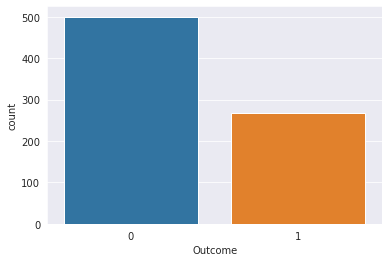

```python
sns.countplot("Outcome", data=diabetes);
```

We can see that the ratio of Outcomes is 0:1 :: 65% : 35% (which is not bad and acceptable). Though we can use Stratified sampling during our train-test-split exercise to handle the class imbalance.

```python
#Descriptive Statistics - Five Point Summary
diabetes.describe().T
```

|  | count | mean | std | min | 25% | 50% | 75% | max |
| --- | --- | --- | --- | --- | --- | --- | --- | --- |
| Pregnancies | 768.0 | 3.845052 | 3.369578 | 0.000 | 1.00000 | 3.0000 | 6.00000 | 17.00 |
| Glucose | 768.0 | 120.894531 | 31.972618 | 0.000 | 99.00000 | 117.0000 | 140.25000 | 199.00 |
| BloodPressure | 768.0 | 69.105469 | 19.355807 | 0.000 | 62.00000 | 72.0000 | 80.00000 | 122.00 |
| SkinThickness | 768.0 | 20.536458 | 15.952218 | 0.000 | 0.00000 | 23.0000 | 32.00000 | 99.00 |
| Insulin | 768.0 | 79.799479 | 115.244002 | 0.000 | 0.00000 | 30.5000 | 127.25000 | 846.00 |
| BMI | 768.0 | 31.992578 | 7.884160 | 0.000 | 27.30000 | 32.0000 | 36.60000 | 67.10 |
| DiabetesPedigreeFunction | 768.0 | 0.471876 | 0.331329 | 0.078 | 0.24375 | 0.3725 | 0.62625 | 2.42 |
| Age | 768.0 | 33.240885 | 11.760232 | 21.000 | 24.00000 | 29.0000 | 41.00000 | 81.00 |
| Outcome | 768.0 | 0.348958 | 0.476951 | 0.000 | 0.00000 | 0.0000 | 1.00000 | 1.00 |

Let us plot the Histograms for all the numeric features to understand their distribution.

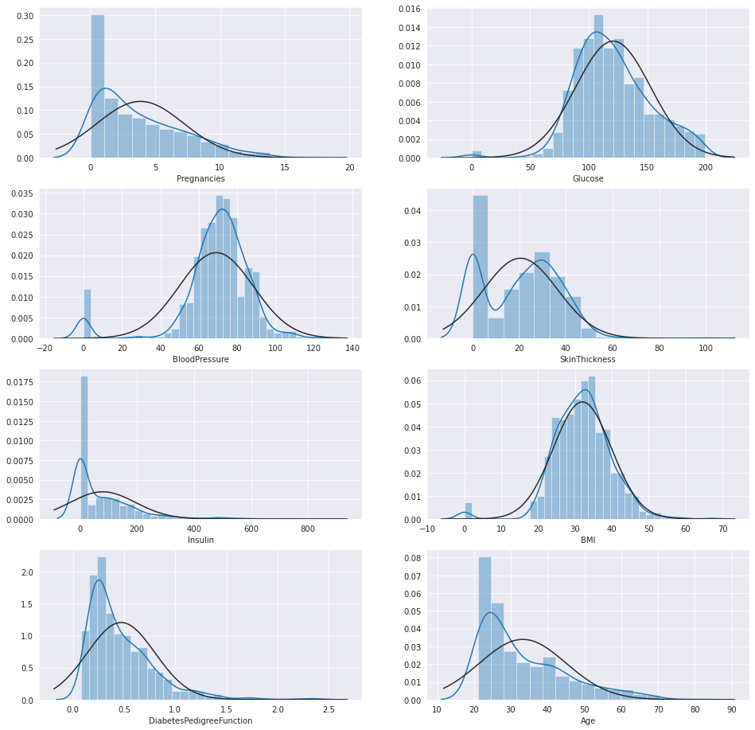

```python
#Distribution of each feature

sns.set_style("darkgrid")

fig, ax2 = plt.subplots(4, 2, figsize=(16, 16))

sns.distplot(diabetes['Pregnancies'],ax=ax2[0][0], fit=norm)
sns.distplot(diabetes['Glucose'],ax=ax2[0][1], fit=norm)
sns.distplot(diabetes['BloodPressure'],ax=ax2[1][0], fit=norm)
sns.distplot(diabetes['SkinThickness'],ax=ax2[1][1], fit=norm)
sns.distplot(diabetes['Insulin'],ax=ax2[2][0], fit=norm)
sns.distplot(diabetes['BMI'],ax=ax2[2][1], fit=norm)
sns.distplot(diabetes['DiabetesPedigreeFunction'],ax=ax2[3][0], fit=norm)
sns.distplot(diabetes['Age'],ax=ax2[3][1], fit=norm)
```

Let us observe the Outliers and Quantile distribution of data using BoxPlots.

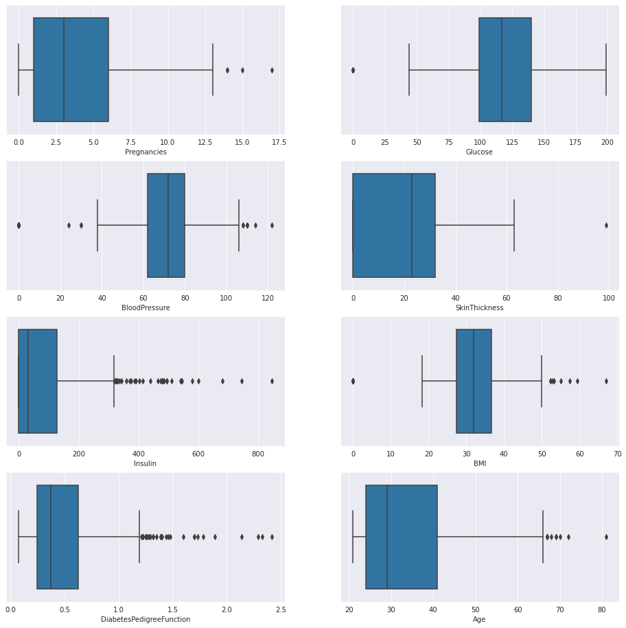

```python
#Outliers analysis of each feature

sns.set_style("darkgrid")

fig, ax2 = plt.subplots(4, 2, figsize=(16, 16))

sns.boxplot(diabetes['Pregnancies'],ax=ax2[0][0])
sns.boxplot(diabetes['Glucose'],ax=ax2[0][1])
sns.boxplot(diabetes['BloodPressure'],ax=ax2[1][0])
sns.boxplot(diabetes['SkinThickness'],ax=ax2[1][1])
sns.boxplot(diabetes['Insulin'],ax=ax2[2][0])
sns.boxplot(diabetes['BMI'],ax=ax2[2][1])
sns.boxplot(diabetes['DiabetesPedigreeFunction'],ax=ax2[3][0])
sns.boxplot(diabetes['Age'],ax=ax2[3][1])
```

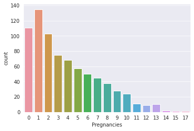

```python
sns.countplot("Pregnancies", data=diabetes);
```

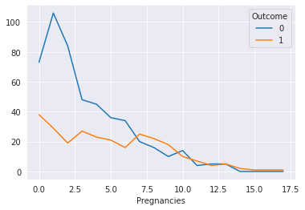

```python
pd.crosstab(diabetes["Pregnancies"], diabetes["Outcome"]).plot()
```

Let us check the bivariate scatterplots across all the feature combinations

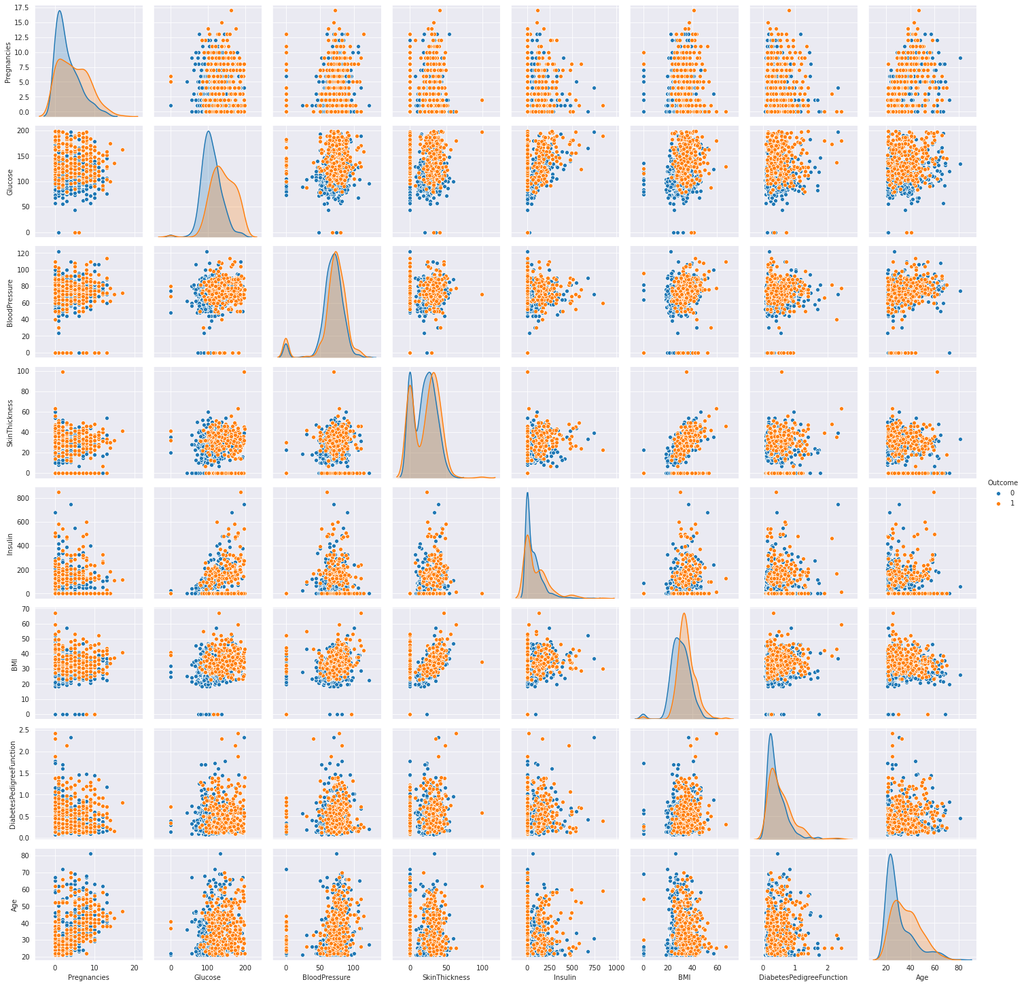

```python
plt.figure(figsize=(10,10))
sns.pairplot(diabetes, diag_kind='kde', hue="Outcome")
plt.show()
```

Let us check the bivariate regression plots for all the feature combinations

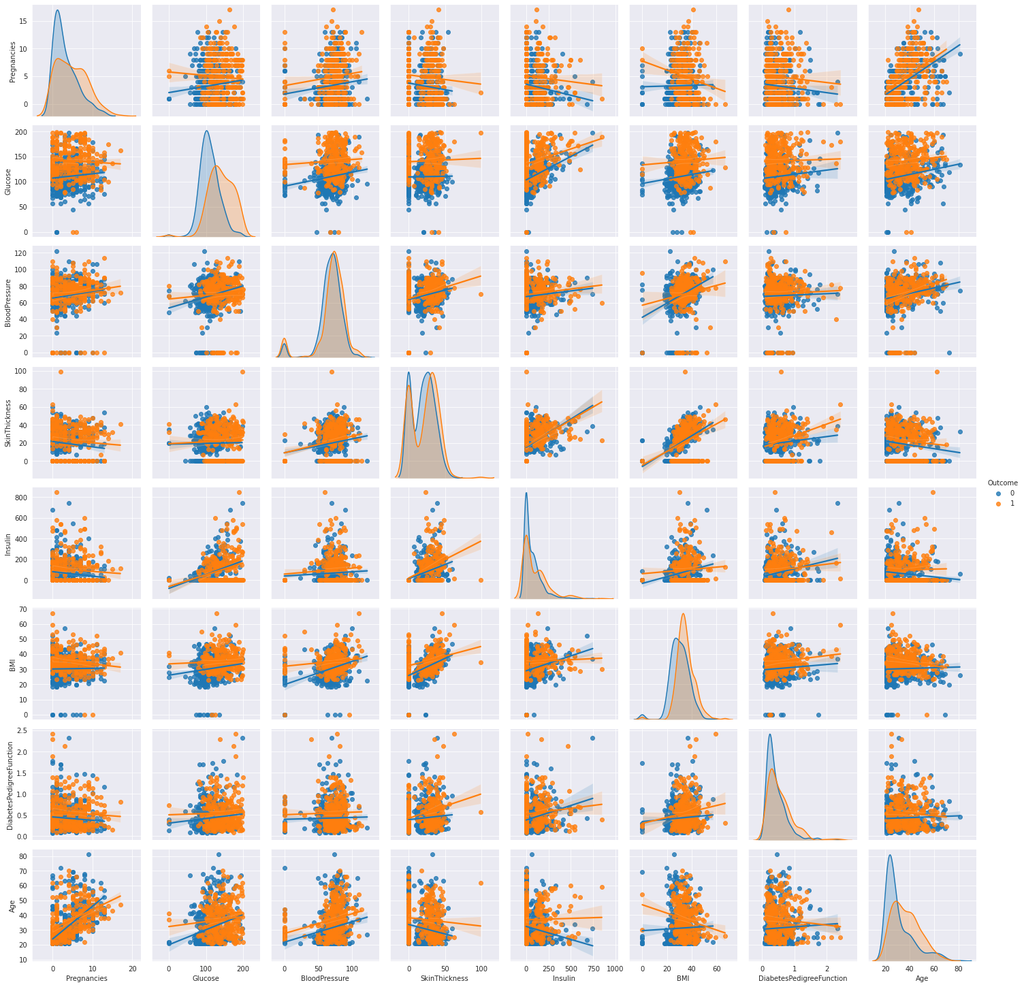

```python
plt.figure(figsize=(10,10))
sns.pairplot(diabetes, kind='reg', hue='Outcome')
plt.show()
```

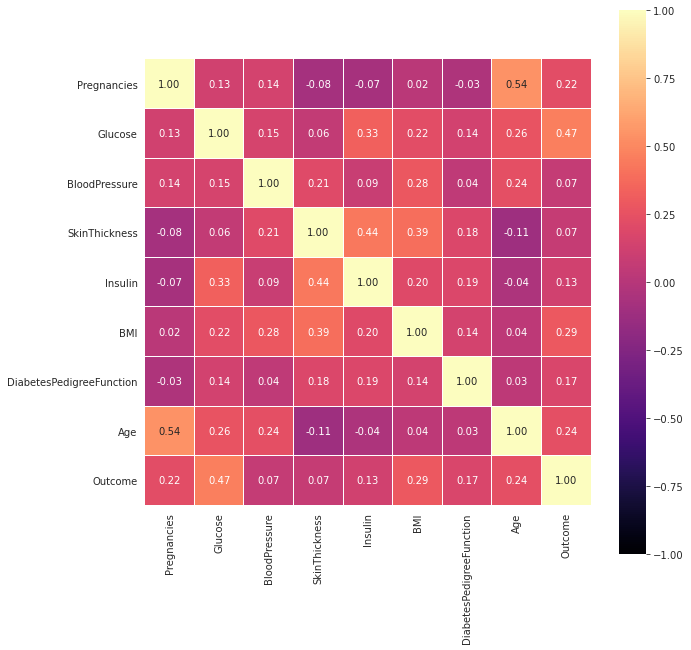

```python
plt.figure(figsize=(10,10))
sns.heatmap(diabetes.corr(), cmap='magma', vmin = -1, vmax = 1, annot=True, fmt="0.2f", square=True, linewidths=0.2)
plt.show()
```

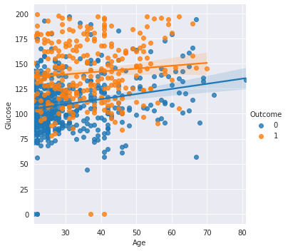

```python
sns.lmplot("Age", "Glucose", data=diabetes, hue='Outcome');
```

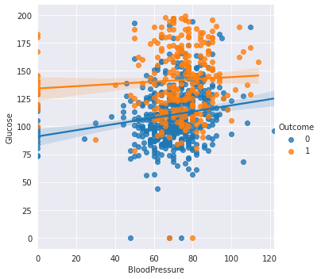

```python
sns.lmplot("BloodPressure", "Glucose", data=diabetes, hue='Outcome');
```

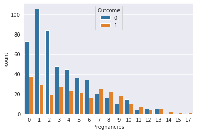

```python
sns.countplot("Pregnancies", hue="Outcome", data=diabetes)
```

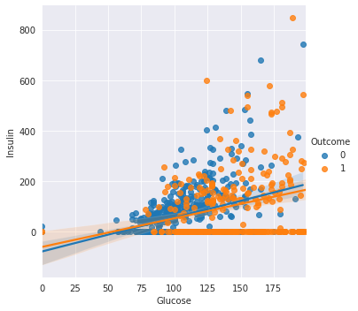

```python
sns.lmplot(y="Insulin",x="Glucose", hue="Outcome", data=diabetes);
```

# Data Preprocessing

1. Split the data into train and test
2. Impute for Missing Values
3. Data Transformation (Scaling)

```python
diabetes.columns
```

```
Index(['Pregnancies', 'Glucose', 'BloodPressure', 'SkinThickness', 'Insulin',
       'BMI', 'DiabetesPedigreeFunction', 'Age', 'Outcome'],
      dtype='object')
```

```python
#All features except Pregnancies - replacing 0s with NaNs
diabetes[['Glucose', 'BloodPressure', 'SkinThickness', 'Insulin', 'BMI', 'DiabetesPedigreeFunction', 'Age']] = diabetes[['Glucose', 'BloodPressure', 'SkinThickness', 'Insulin', 'BMI', 'DiabetesPedigreeFunction', 'Age']].replace(to_replace=0, value=np.nan)
```

```python
diabetes.head()
```

|  | Pregnancies | Glucose | BloodPressure | SkinThickness | Insulin | BMI | DiabetesPedigreeFunction | Age | Outcome |
| --- | --- | --- | --- | --- | --- | --- | --- | --- | --- |
| 0 | 6 | 148.0 | 72.0 | 35.0 | NaN | 33.6 | 0.627 | 50 | 1 |
| 1 | 1 | 85.0 | 66.0 | 29.0 | NaN | 26.6 | 0.351 | 31 | 0 |
| 2 | 8 | 183.0 | 64.0 | NaN | NaN | 23.3 | 0.672 | 32 | 1 |
| 3 | 1 | 89.0 | 66.0 | 23.0 | 94.0 | 28.1 | 0.167 | 21 | 0 |
| 4 | 0 | 137.0 | 40.0 | 35.0 | 168.0 | 43.1 | 2.288 | 33 | 1 |

Let us visualise the NaNs now in the dataset

```python
diabetes.info()
```

```
<class 'pandas.core.frame.DataFrame'>
RangeIndex: 768 entries, 0 to 767
Data columns (total 9 columns):
 #   Column                    Non-Null Count  Dtype
---  ------                    --------------  -----
 0   Pregnancies               768 non-null    int64
 1   Glucose                   763 non-null    float64
 2   BloodPressure             733 non-null    float64
 3   SkinThickness             541 non-null    float64
 4   Insulin                   394 non-null    float64
 5   BMI                       757 non-null    float64
 6   DiabetesPedigreeFunction  768 non-null    float64
 7   Age                       768 non-null    int64
 8   Outcome                   768 non-null    int64
dtypes: float64(6), int64(3)
memory usage: 54.1 KB
```

```python
print("Number of missing values in dataframe : \n", diabetes.isnull().sum())
print("-------------------------")
print("Percentage of columnwise missing values in dataframe : \n", round(diabetes.isnull().mean() * 100, 2))
```

```
Number of missing values in dataframe :
 Pregnancies                   0
Glucose                       5
BloodPressure                35
SkinThickness               227
Insulin                     374
BMI                          11
DiabetesPedigreeFunction      0
Age                           0
Outcome                       0
dtype: int64
-------------------------
Percentage of columnwise missing values in dataframe :
 Pregnancies                  0.00
Glucose                      0.65
BloodPressure                4.56
SkinThickness               29.56
Insulin                     48.70
BMI                          1.43
DiabetesPedigreeFunction     0.00
Age                          0.00
Outcome                      0.00
dtype: float64
```

Imputing the NaNs with Median values

```python
from sklearn.impute import SimpleImputer
imputer = SimpleImputer(missing_values=np.nan, strategy='median')

diabetes_cols = diabetes.columns

diabetes = imputer.fit_transform(diabetes)

diabetes = pd.DataFrame(diabetes, columns = diabetes_cols)

diabetes.head()
```

|  | Pregnancies | Glucose | BloodPressure | SkinThickness | Insulin | BMI | DiabetesPedigreeFunction | Age | Outcome |
| --- | --- | --- | --- | --- | --- | --- | --- | --- | --- |
| 0 | 6.0 | 148.0 | 72.0 | 35.0 | 125.0 | 33.6 | 0.627 | 50.0 | 1.0 |
| 1 | 1.0 | 85.0 | 66.0 | 29.0 | 125.0 | 26.6 | 0.351 | 31.0 | 0.0 |
| 2 | 8.0 | 183.0 | 64.0 | 29.0 | 125.0 | 23.3 | 0.672 | 32.0 | 1.0 |
| 3 | 1.0 | 89.0 | 66.0 | 23.0 | 94.0 | 28.1 | 0.167 | 21.0 | 0.0 |
| 4 | 0.0 | 137.0 | 40.0 | 35.0 | 168.0 | 43.1 | 2.288 | 33.0 | 1.0 |

Let us check the shapes of predictors and target

```python
X = diabetes[['Pregnancies', 'Glucose', 'BloodPressure', 'SkinThickness', 'Insulin', 'BMI', 'DiabetesPedigreeFunction', 'Age']]
y = diabetes['Outcome']
print("Shape of X :", X.shape)
print("Shape of y :",y.shape)
```

```
Shape of X : (768, 8)
Shape of y : (768,)
```

Splitting the data into train and test sets. We will use Stratified sampling to handle class imbalance.

```python
X_train, X_test, y_train, y_test = train_test_split(X, y, test_size=0.30, stratify=diabetes["Outcome"], random_state=24)
```

```python
X_train.shape
```

```
(537, 8)
```

```python
y_train.shape
```

```
(537,)
```

```python
X_test.shape
```

```
(231, 8)
```

```python
y_test.shape
```

```
(231,)
```

```python
X_train.sample(3)
```

|  | Pregnancies | Glucose | BloodPressure | SkinThickness | Insulin | BMI | DiabetesPedigreeFunction | Age |
| --- | --- | --- | --- | --- | --- | --- | --- | --- |
| 122 | 2.0 | 107.0 | 74.0 | 30.0 | 100.0 | 33.6 | 0.404 | 23.0 |
| 660 | 10.0 | 162.0 | 84.0 | 29.0 | 125.0 | 27.7 | 0.182 | 54.0 |
| 79 | 2.0 | 112.0 | 66.0 | 22.0 | 125.0 | 25.0 | 0.307 | 24.0 |

```python
X_test.sample(3)
```

|  | Pregnancies | Glucose | BloodPressure | SkinThickness | Insulin | BMI | DiabetesPedigreeFunction | Age |
| --- | --- | --- | --- | --- | --- | --- | --- | --- |
| 612 | 7.0 | 168.0 | 88.0 | 42.0 | 321.0 | 38.2 | 0.787 | 40.0 |
| 244 | 2.0 | 146.0 | 76.0 | 35.0 | 194.0 | 38.2 | 0.329 | 29.0 |
| 54 | 7.0 | 150.0 | 66.0 | 42.0 | 342.0 | 34.7 | 0.718 | 42.0 |

Before we fit the model, let us do scaling of features to handle outliers and different feature scales

```python
from sklearn.preprocessing import MinMaxScaler
mmScaler = MinMaxScaler()
X_train_scaled = mmScaler.fit_transform(X_train.values)
X_test_scaled = mmScaler.fit_transform(X_test.values)

X_train = pd.DataFrame(X_train_scaled, index=X_train.index, columns=X_train.columns)
X_test = pd.DataFrame(X_test_scaled, index=X_test.index, columns=X_test.columns)
```

```python
X_train.sample(3)
```

|  | Pregnancies | Glucose | BloodPressure | SkinThickness | Insulin | BMI | DiabetesPedigreeFunction | Age |
| --- | --- | --- | --- | --- | --- | --- | --- | --- |
| 684 | 0.294118 | 0.597403 | 0.565217 | 0.239130 | 0.133413 | 0.342233 | 0.238014 | 0.941176 |
| 555 | 0.411765 | 0.519481 | 0.434783 | 0.282609 | 0.241587 | 0.177184 | 0.032962 | 0.313725 |
| 604 | 0.235294 | 0.902597 | 0.456522 | 0.239130 | 0.133413 | 0.247573 | 0.054795 | 0.294118 |

```python
X_test.sample(3)
```

|  | Pregnancies | Glucose | BloodPressure | SkinThickness | Insulin | BMI | DiabetesPedigreeFunction | Age |
| --- | --- | --- | --- | --- | --- | --- | --- | --- |
| 27 | 0.071429 | 0.286713 | 0.488372 | 0.145833 | 0.178082 | 0.102249 | 0.225344 | 0.016667 |
| 737 | 0.571429 | 0.062937 | 0.558140 | 0.312500 | 0.155251 | 0.282209 | 0.287603 | 0.350000 |
| 688 | 0.071429 | 0.587413 | 0.581395 | 0.375000 | 0.238965 | 0.120654 | 0.413223 | 0.033333 |